# exercise3

yixun

2024-02-22

```r
library(readr)
library(quanteda)
library(quanteda.textstats)
library(stringdist)
library(dplyr)
library(tibble)
library(ggplot2)
```

#create tweets dataset

```r
tweets <- readRDS(gzcon(url("https://github.com/cjbarrie/CTA-ED/blob/main/data/comparison-complexity/cabinet_tweets.rds?raw=true")))
```

#look data

```r
head(tweets)
```

```
## # A tibble: 6 × 3
##   username   tweet                                                    date
##   <chr>      <chr>                                                    <date>
## 1 aluncairns "A good luck message to Chris Coleman’s squad @FAWales … 2017-10-09
## 2 aluncairns ".@AlunCairns “The close relationship between industry … 2017-10-09
## 3 aluncairns "@BarclaysCorp &amp; @SPTS_Tech \"voice of Welsh Manufa… 2017-10-09
## 4 aluncairns "Today we announced plans to ban the sale of ivory in t… 2017-10-06
## 5 aluncairns "Unbeaten Wales overcome Georgia to boost their @FIFAWo… 2017-10-06
## 6 aluncairns ".@GutoAberconwy marks 25 years of engine production @t… 2017-10-06
```

#delete repeated values

#calculate how many usernames in this dataset

```r
unique(tweets$username)
```

```
##  [1] "aluncairns"      "amberrudduk"     "andrealeadsom"   "borisjohnson"
##  [5] "brandonlewis"    "damiangreen"     "damianhinds"     "daviddavismp"
##  [9] "davidgauke"      "davidmundelldct" "dlidington"      "gavinwilliamson"
## [13] "gregclarkmp"     "jbrokenshire"    "jeremy_hunt"     "juliansmithuk"
## [17] "justinegreening" "liamfox"         "michaelgove"     "pennymordaunt"
## [21] "philiphammonduk" "sajidjavid"      "theresa_may"     "trussliz"
```

```r
length(unique(tweets$username))
```

```
## [1] 24
```

#create corpus dataset, specifying the text field is tweet from tweets dataset

#ceated a variable(username) in corpus dataset

#print corpus

```r
tweets_corpus <- corpus(tweets, text_field = "tweet")

docvars(tweets_corpus, "username") <- tweets$username

tweets_corpus
```

```
## Corpus consisting of 10,321 documents and 2 docvars.
## text1 :
## "A good luck message to Chris Coleman’s squad @FAWales ahead ..."
##
## text2 :
## ".@AlunCairns “The close relationship between industry and go..."
##
## text3 :
## "@BarclaysCorp &amp; @SPTS_Tech "voice of Welsh Manufacturing..."
##
## text4 :
## "Today we announced plans to ban the sale of ivory in the UK...."
##
## text5 :
## "Unbeaten Wales overcome Georgia to boost their @FIFAWorldCup..."
##
## text6 :
## ".@GutoAberconwy marks 25 years of engine production @toyotaf..."
##
## [ reached max_ndoc ... 10,315 more documents ]
```

#reformat dataset(corpus)’s matrix

#remove punctuation and stopwords

```r
dfmat <- dfm(tokens(tweets_corpus),
             remove_punct = TRUE,
             remove = stopwords("english"))
dfmat
```

```
## Document-feature matrix of: 10,321 documents, 26,955 features (99.95% sparse) and 2 docvars.
##        features
## docs    good luck message chris coleman’s squad @fawales ahead tonight’s
##   text1    1    1       1     1         1     1        1     1         1
##   text2    0    0       0     0         0     0        0     0         0
##   text3    0    0       0     0         0     0        0     0         0
##   text4    0    0       0     0         0     0        0     0         0
##   text5    0    0       0     0         0     0        0     0         0
##   text6    0    0       0     0         0     0        0     0         0
##        features
## docs    crucial
##   text1       1
##   text2       0
##   text3       0
##   text4       0
##   text5       0
##   text6       0
## [ reached max_ndoc ... 10,315 more documents, reached max_nfeat ... 26,945 more features ]
```

#euclidean method:calculate the euclidean distance between usernames

#create a matrix(euclidean_dist), using data from dfmat

#according to unique username to divide euclidean_dist into diffferent groups

#calulate the similarity between documents, “margin” means consider what to calculate similarity

#keep the first 5 columns and volumns

```r
euclidean_dist <- dfmat %>%
  dfm_group(groups = username) %>%
  textstat_dist(margin = "documents", method = "euclidean")

euclidean_dist[1:5,1:5]
```

```
## 5 x 5 Matrix of class "dspMatrix"
##               aluncairns amberrudduk andrealeadsom borisjohnson brandonlewis
## aluncairns        0.0000    341.4572      383.1762     340.8753     700.3578
## amberrudduk     341.4572      0.0000      323.7514     191.5020     723.7251
## andrealeadsom   383.1762    323.7514        0.0000     305.6665     603.0348
## borisjohnson    340.8753    191.5020      305.6665       0.0000     673.6965
## brandonlewis    700.3578    723.7251      603.0348     673.6965       0.0000
```

#create a matrix

```r
euclidmat <- as.matrix(euclidean_dist)
```

#exclude Therasa May herself’s data, and this dataste is only related to Therasa May

```r
euclidmatdf <- as.data.frame(euclidmat[23, c(1:22,24)])
```

#rename euclideanmardf to corr_may

```r
colnames(euclidmatdf) <- "corr_may"

euclidmatdf <- tibble::rownames_to_column(euclidmatdf,"username")
```

#visualize

#ggplot:based on this dataset

#geom_point: x axis reordered username and rank username from high to low (according to euclidean distance), y axis is the value of euclidean distance

#coord_flip: this section flips the axes and swaps the x and y axes to better show the horizontal labels.

#x and y lab: names

#theme_minimal: topic

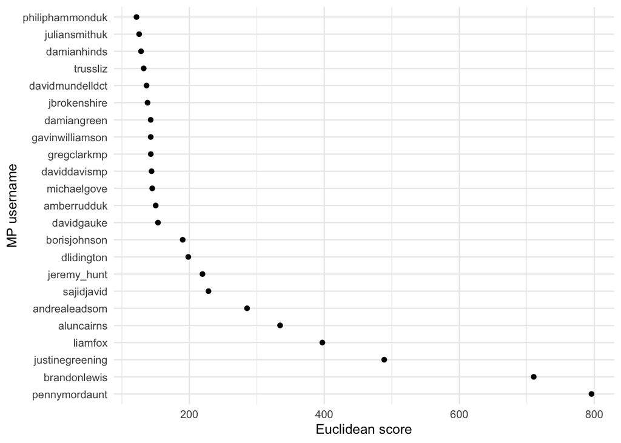

```r
ggplot(euclidmatdf) +
  geom_point(aes(x=reorder(username, -corr_may), y= corr_may)) +
  coord_flip() +
  xlab("MP username") +
  ylab("Euclidean score") +
  theme_minimal()
```

#manhattan method

```r
manhattan_dist <- dfmat %>%
  dfm_group(groups = username) %>%
  textstat_dist(margin = "documents", method = "manhattan")

manhattan_dist[1:5,1:5]
```

```
## 5 x 5 Matrix of class "dspMatrix"
##               aluncairns amberrudduk andrealeadsom borisjohnson brandonlewis
## aluncairns             0        8283         12570         8990        19611
## amberrudduk         8283           0         11347         5497        18632
## andrealeadsom      12570       11347             0        11670        18061
## borisjohnson        8990        5497         11670            0        19073
## brandonlewis       19611       18632         18061        19073            0
```

```r
manhatmat <- as.matrix(manhattan_dist)
```

```r
manhatmatdf <- as.data.frame(manhatmat[23,c(1:22,24)])
```

```r
colnames(manhatmatdf) <- "corr_may"

manhatmatdf<- tibble::rownames_to_column(manhatmatdf, "username")
```

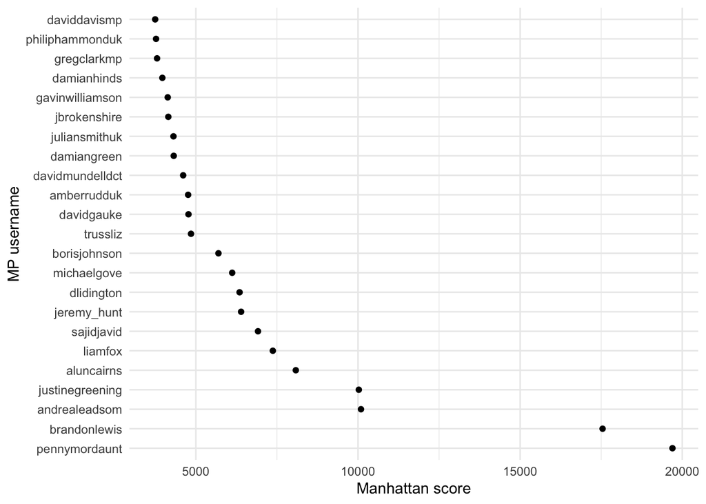

```r
ggplot(manhatmatdf) +
  geom_point(aes(x=reorder(username, -corr_may), y= corr_may)) +
  coord_flip() +
  xlab("MP username") +
  ylab("Manhattan score") +
  theme_minimal()
```

#complexity

#create speeches dataset

```r
speeches  <- readRDS(gzcon(url("https://github.com/cjbarrie/CTA-ED/blob/main/data/comparison-complexity/speeches.rds?raw=true")))
```

#coleman-liau

# used coleman-liau measure to calculats speeches text’s complexity

#extract outcome from dataset, and stroed in coleman.liau

```r
speeches$coleman.liau <- textstat_readability(speeches$text, measure = "Coleman.Liau")
speeches$coleman.liau <- speeches$coleman.liau$Coleman.Liau
```

#create corpus dataset

#used speakers as group criteria

#calculate mean, standard deviation, how many speakers

# calsulate every speaker’s standard error, confidence interval(95%)

```r
sum_corpus <- speeches %>%
  group_by(speaker) %>%
  summarise(mean = mean(coleman.liau, na.rm=TRUE),
                   SD=sd(coleman.liau, na.rm=TRUE),
                   N=length(speaker))

sum_corpus$se <- sum_corpus$SD / sqrt(sum_corpus$N)
sum_corpus$min <- sum_corpus$mean - 1.96*sum_corpus$se
sum_corpus$max <- sum_corpus$mean + 1.96*sum_corpus$se
```

```r
sum_corpus
```

```
## # A tibble: 4 × 7
##   speaker          mean    SD     N    se   min   max
##   <chr>           <dbl> <dbl> <int> <dbl> <dbl> <dbl>
## 1 D. Cameron       49.4  3.95   456 0.185  49.0  49.8
## 2 G. Brown         47.6  4.43   277 0.266  47.0  48.1
## 3 J.L.R. Zapatero  43.5  4.05   354 0.215  43.0  43.9
## 4 M. Rajoy         46.5  5.08   389 0.257  46.0  47.0
```

#visualize

#stat = “identity” means the mean for each speaker is shown directly as the height of the bar chart

#geom_errorbar: represents the standard deviation of the Coleman-Liau index mean for each speaker.

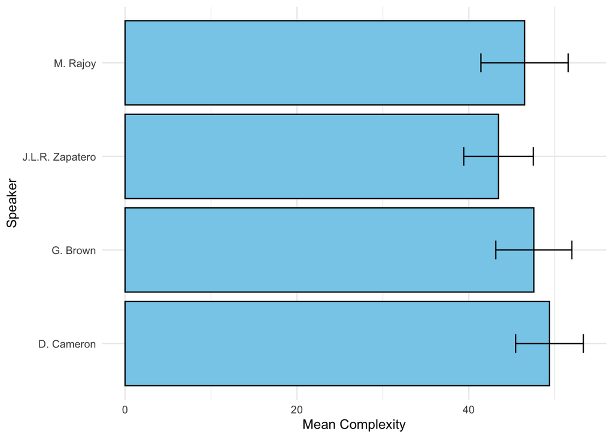

```r
ggplot(sum_corpus, aes(x = speaker, y = mean)) +
  geom_bar(stat = "identity", fill = "skyblue", color = "black") +
  geom_errorbar(aes(ymin = mean - SD, ymax = mean + SD), width = 0.2, color = "black") +
  coord_flip() +
  xlab("Speaker") +
  ylab("Mean Complexity") +
  theme_minimal()
```

#dale-chall

```r
speeches$dale.chall <- textstat_readability(speeches$text, measure = "Dale.Chall")
speeches$dale.chall <- speeches$dale.chall$Dale.Chall
```

```r
sum_corpus <- speeches %>%
  group_by(speaker) %>%
  summarise(mean = mean(dale.chall, na.rm=TRUE),
                   SD=sd(dale.chall, na.rm=TRUE),
                   N=length(speaker))

sum_corpus$se <- sum_corpus$SD / sqrt(sum_corpus$N)
sum_corpus$min <- sum_corpus$mean - 1.96*sum_corpus$se
sum_corpus$max <- sum_corpus$mean + 1.96*sum_corpus$se
```

```r
sum_corpus
```

```
## # A tibble: 4 × 7
##   speaker          mean    SD     N    se   min   max
##   <chr>           <dbl> <dbl> <int> <dbl> <dbl> <dbl>
## 1 D. Cameron       27.8  4.31   456 0.202  27.4  28.2
## 2 G. Brown         23.3  5.40   277 0.325  22.7  24.0
## 3 J.L.R. Zapatero  18.3  6.37   354 0.339  17.6  19.0
## 4 M. Rajoy         22.9  6.41   389 0.325  22.2  23.5
```

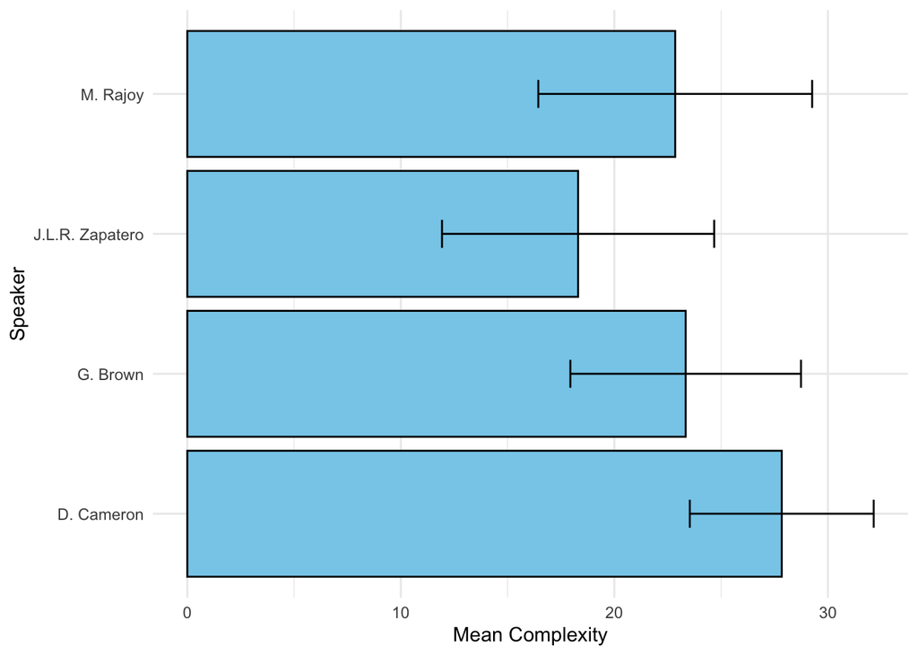

```r
ggplot(sum_corpus, aes(x = speaker, y = mean)) +
  geom_bar(stat = "identity", fill = "skyblue", color = "black") +
  geom_errorbar(aes(ymin = mean - SD, ymax = mean + SD), width = 0.2, color = "black") +
  coord_flip() +
  xlab("Speaker") +
  ylab("Mean Complexity") +
  theme_minimal()
```

#automated readability index

```r
speeches$ari <- textstat_readability(speeches$text, measure = "ARI")
speeches$ari <- speeches$ari$ARI
```

```r
sum_corpus <- speeches %>%
  group_by(speaker) %>%
  summarise(mean = mean(ari, na.rm=TRUE),
                   SD=sd(ari, na.rm=TRUE),
                   N=length(speaker))

sum_corpus$se <- sum_corpus$SD / sqrt(sum_corpus$N)
sum_corpus$min <- sum_corpus$mean - 1.96*sum_corpus$se
sum_corpus$max <- sum_corpus$mean + 1.96*sum_corpus$se
```

```r
sum_corpus
```

```
## # A tibble: 4 × 7
##   speaker          mean    SD     N     se   min   max
##   <chr>           <dbl> <dbl> <int>  <dbl> <dbl> <dbl>
## 1 D. Cameron       10.9  1.99   456 0.0933  10.7  11.1
## 2 G. Brown         14.1  2.77   277 0.166   13.7  14.4
## 3 J.L.R. Zapatero  16.3  3.45   354 0.183   15.9  16.7
## 4 M. Rajoy         14.0  3.10   389 0.157   13.7  14.3
```

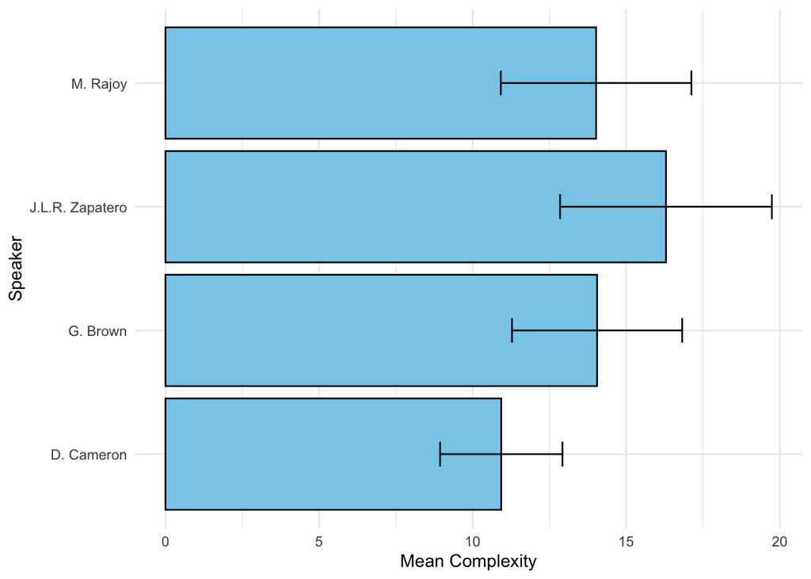

```r
ggplot(sum_corpus, aes(x = speaker, y = mean)) +
  geom_bar(stat = "identity", fill = "skyblue", color = "black") +
  geom_errorbar(aes(ymin = mean - SD, ymax = mean + SD), width = 0.2, color = "black") +
  coord_flip() +
  xlab("Speaker") +
  ylab("Mean Complexity") +
  theme_minimal()
```